# White House Visitors - Explorations - By Day for Latest Month

Earl F Glynn

2023-04-06

Also see `Counts` directory created by script `1-WhiteHouse-Visitors-Processing.Rmd` with frequency counts of values of fields.

# 1 Setup

## 1.1

## 1.2 Constants

```r
DATA_RELEASE  <- "2023-03-30"                                                              ##### (1/4)
```

[December 2022 Visitor Log Records Posted, March 30, 2023](https://www.whitehouse.gov/briefing-room/disclosures/2023/03/30/december-2022-visitor-log-records-posted/)

```r
SOURCE <-  paste0("Source: www.whitehouse.gov/briefing-room/disclosures/2023/03/30/\n",    #####  (2/4)
                  "december-2022-visitor-log-records-posted/")                             #####  (3/4)

stamp   <- paste0("watchdoglab.substack.com\n", format(time.1, "%Y-%m-%d"))
```

```r
EXCEL_LIMIT <- 2^20
```

## 1.3 Packages

```r
library(tidyverse)
```

```r
library(lubridate)   # parse_date_time, mdy_hm
```

```r
library(downloader)  # download
```

```r
library(tools)       # md5sum
```

I/O

```r
library(readxl)      # read_xlsx
library(readr)       # write_csv
library(writexl)     # write_xlsx
```

Display formatting

```r
library(kableExtra)  # kable_styling
```

```r
#library(IRdisplay)   # display_html (needed in Jupyter notebooks)
```

Graphics

```r
library(RColorBrewer)
library(scales)      # comma, comma_format
```

## 1.4 ggplot theme

[ggplot Themes Gallery](https://www.datanovia.com/en/blog/ggplot-themes-gallery/)

```r
theme_set(theme_minimal() +

            theme(
                   axis.text             = element_text(size =  9),
                   axis.title            = element_text(size = 11),

                   plot.caption          = element_text(size =  10,
                                                        hjust = c(0.0,1.0)),
                   plot.caption.position = "plot",

                   plot.title.position   = "plot",
                   plot.title            = element_text(size = 14),
                   plot.subtitle         = element_text(size = 12),

                   strip.background      = element_rect(fill = "aliceblue"),
                   strip.text            = element_text(size = 14),

                   panel.grid.minor.x    = element_blank(),
                   panel.grid.minor.y    = element_blank()
                 )
         )
```

```r
COLOR_BAR     <- "skyblue"
COLOR_OUTLINE <- "grey80"
```

## 1.5 Helper functions

### 1.5.1 Show

```r
Show <- function(data, caption="", bigMark="",
                 height = NULL, width = NULL, ...)
{
  data                                       |>
  kable("html", caption=caption,
        format.args=list(big.mark=bigMark))  |>
  kable_styling(bootstrap_options=c("striped", "bordered", "condensed"),
                position="left",
                full_width=FALSE, ...)       |>
  scroll_box(height = height, width = width)
}
```

# 2 Read White House Visitor Data

## 2.1 All Data

Combined from all reports

```r
wh <-
  read_csv(paste0("White-House-Visitor-Log-Data-",
                  DATA_RELEASE,
                  ".csv"),
           guess_max = EXCEL_LIMIT,
           show_col_types = FALSE)   |>
  select(-`Terminal Suffix`)         |>       # identical to `Last Updated By`
  mutate(GROUP = factor(GROUP,                # Define order for groups
                        levels = c("POTUS", "VPOTUS", "FLOTUS",
                                   "Staff", "Tourist")))

dim(wh)
```

```
[1] 364094     44
```

## 2.2 Counts by Month

```r
monthCounts <-
  wh |>
    filter(!is.na(RELEASEDATE)) |>  # ignore two records with missing value
    group_by(RELEASEDATE) %>%
    count()

monthCounts |> Show(height = "200px")
```

| RELEASEDATE | n |
| --- | --- |
| 2021-05-07 | 400 |
| 2021-06-01 | 1064 |
| 2021-06-29 | 1215 |
| 2021-07-29 | 1509 |
| 2021-08-30 | 1742 |
| 2021-10-01 | 2154 |
| 2021-11-01 | 5616 |
| 2021-12-03 | 2094 |
| 2022-01-07 | 2671 |
| 2022-02-04 | 2858 |
| 2022-03-11 | 4608 |
| 2022-04-13 | 15474 |
| 2022-05-04 | 1184 |
| 2022-05-31 | 2155 |
| 2022-07-01 | 6063 |
| 2022-08-02 | 13519 |
| 2022-08-30 | 20099 |
| 2022-10-04 | 17396 |
| 2022-10-31 | 39758 |
| 2022-11-30 | 31035 |
| 2022-12-30 | 37254 |
| 2023-01-30 | 39277 |
| 2023-02-28 | 27929 |
| 2023-03-30 | 87018 |

Normally will want the most recent month, but the filter here could be changed to pick any month.

```r
targetRelease <- monthCounts |> select(RELEASEDATE) |> tail(1) |> pull()        ##### 4/4
targetRelease
```

```
[1] "2023-03-30"
```

For filenames

```r
targetMonth <-  targetRelease %m-% months(3) |> str_sub(1, 7)
targetMonth
```

```
[1] "2022-12"
```

```r
targetMonthName <- format(targetRelease %m-% months(3), "%B %Y")
targetMonthName
```

```
[1] "December 2022"
```

```r
wh <-
  wh  |>
  filter(RELEASEDATE == targetRelease)

dim(wh)
```

```
[1] 87018    44
```

# 3 Define Events

Unique events mostly defined by

```r
events <-
  wh  |>
  select(GROUP, APPT_START_DATE,
         Event, LOCATION, `Total People`)                    |>
  unique()                                                   |>
  mutate(              # YYYY-MM-DD yy:mm:ss
          Year       = substr(APPT_START_DATE,  1,  4) |>
                       as.numeric(),
          Month      = substr(APPT_START_DATE,  6,  7) |>
                       as.numeric(),
          Day        = substr(APPT_START_DATE,  9, 10) |>
                       as.numeric(),
          Hour       = substr(APPT_START_DATE, 12, 13) |>
                       as.numeric()
        )

dim(events)
```

```
[1] 9547    9
```

```r
events |> tail(3) |> Show()
```

| GROUP | APPT_START_DATE | Event | LOCATION | Total People | Year | Month | Day | Hour |
| --- | --- | --- | --- | --- | --- | --- | --- | --- |
| Staff | 2022-12-31 18:45:00 | U11393 | wh\|west wing | 4 | 2022 | 12 | 31 | 18 |
| Staff | 2022-12-31 18:45:00 | U11599 | wh\|west wing | 1 | 2022 | 12 | 31 | 18 |
| Staff | 2022-12-31 21:00:00 | U10254 | oeob\|bowling alley - 037 | 18 | 2022 | 12 | 31 | 21 |

```r
write_xlsx(events,
           paste0("Target-", targetMonth, "-",
                  "White-House-Events-",
                  DATA_RELEASE, ".xlsx"))
```

## 3.1 Events by Group

```r
eventCountsByGroup <-
  events                      |>
  group_by(`Total People`,
           GROUP)             |>
  summarize(n = n(),
            .groups = "drop") |>
  spread(GROUP, n, fill = 0)  |>
  mutate(Events = rowSums(across(POTUS:Tourist)))

dim(eventCountsByGroup)
```

```
[1] 189   7
```

```r
eventCountsByGroup |>
  Show(bigMark = ",", height = "300px")
```

| Total People | POTUS | VPOTUS | FLOTUS | Staff | Tourist | Events |
| --- | --- | --- | --- | --- | --- | --- |
| 1 | 400 | 2 | 1 | 1,965 | 955 | 3,323 |
| 2 | 22 | 0 | 1 | 646 | 1,011 | 1,680 |
| 3 | 12 | 4 | 0 | 374 | 462 | 852 |
| 4 | 5 | 1 | 0 | 289 | 695 | 990 |
| 5 | 4 | 0 | 0 | 223 | 412 | 639 |
| 6 | 5 | 0 | 0 | 340 | 527 | 872 |
| 7 | 2 | 0 | 0 | 64 | 83 | 149 |
| 8 | 0 | 0 | 0 | 40 | 62 | 102 |
| 9 | 0 | 1 | 0 | 39 | 36 | 76 |
| 10 | 0 | 0 | 0 | 25 | 42 | 67 |
| 11 | 2 | 0 | 0 | 29 | 16 | 47 |
| 12 | 2 | 0 | 0 | 25 | 33 | 60 |
| 13 | 3 | 0 | 0 | 23 | 12 | 38 |
| 14 | 2 | 0 | 0 | 16 | 23 | 41 |
| 15 | 0 | 0 | 0 | 15 | 15 | 30 |
| 16 | 0 | 0 | 0 | 17 | 9 | 26 |
| 17 | 0 | 0 | 0 | 18 | 6 | 24 |
| 18 | 0 | 0 | 0 | 21 | 8 | 29 |
| 19 | 0 | 0 | 0 | 21 | 2 | 23 |
| 20 | 1 | 0 | 0 | 10 | 4 | 15 |
| 21 | 0 | 0 | 0 | 6 | 1 | 7 |
| 22 | 0 | 0 | 0 | 7 | 3 | 10 |
| 23 | 2 | 0 | 0 | 9 | 4 | 15 |
| 24 | 0 | 0 | 0 | 6 | 5 | 11 |
| 25 | 0 | 0 | 0 | 2 | 10 | 12 |
| 26 | 0 | 0 | 0 | 2 | 6 | 8 |
| 27 | 0 | 0 | 0 | 2 | 0 | 2 |
| 28 | 2 | 0 | 0 | 1 | 3 | 6 |
| 29 | 2 | 0 | 0 | 1 | 7 | 10 |
| 30 | 0 | 0 | 0 | 1 | 4 | 5 |

[output cut: 159 more lines]

```r
write_xlsx(eventCountsByGroup,
           paste0("Target-", targetMonth, "-",
                  "White-House-Events-TotalPeople-by-Group-",
                  DATA_RELEASE, ".xlsx"))
```

## 3.2 Events By Day

```r
eventCountsByDay <-
  events                      |>
  group_by(Day, GROUP)        |>
  summarize(n = n(),
            .groups = "drop") |>
  spread(GROUP, n, fill = 0)  |>
  mutate(Events = rowSums(across(POTUS:Tourist)))

dim(eventCountsByDay)
```

```
[1] 31  7
```

```r
eventCountsByDay |>
  Show(bigMark = ",", height = "300px")
```

| Day | POTUS | VPOTUS | FLOTUS | Staff | Tourist | Events |
| --- | --- | --- | --- | --- | --- | --- |
| 1 | 33 | 0 | 0 | 256 | 0 | 289 |
| 2 | 0 | 0 | 0 | 192 | 0 | 192 |
| 3 | 0 | 0 | 0 | 175 | 230 | 405 |
| 4 | 13 | 0 | 0 | 33 | 0 | 46 |
| 5 | 25 | 0 | 0 | 141 | 0 | 166 |
| 6 | 0 | 1 | 0 | 239 | 357 | 597 |
| 7 | 31 | 2 | 0 | 275 | 255 | 563 |
| 8 | 27 | 0 | 0 | 211 | 0 | 238 |
| 9 | 38 | 0 | 0 | 198 | 430 | 666 |
| 10 | 35 | 0 | 0 | 91 | 0 | 126 |
| 11 | 21 | 0 | 0 | 95 | 243 | 359 |
| 12 | 43 | 0 | 0 | 191 | 0 | 234 |
| 13 | 35 | 0 | 0 | 259 | 312 | 606 |
| 14 | 11 | 0 | 0 | 155 | 0 | 166 |
| 15 | 32 | 0 | 0 | 179 | 34 | 245 |
| 16 | 45 | 0 | 0 | 253 | 773 | 1,071 |
| 17 | 0 | 0 | 0 | 162 | 448 | 610 |
| 18 | 0 | 1 | 0 | 141 | 229 | 371 |
| 19 | 47 | 7 | 0 | 192 | 111 | 357 |
| 20 | 16 | 0 | 2 | 210 | 0 | 228 |
| 21 | 28 | 1 | 0 | 150 | 0 | 179 |
| 22 | 19 | 0 | 0 | 116 | 1 | 136 |
| 23 | 0 | 0 | 0 | 156 | 1,295 | 1,451 |
| 24 | 0 | 0 | 0 | 10 | 0 | 10 |
| 25 | 0 | 0 | 0 | 4 | 0 | 4 |
| 26 | 0 | 0 | 0 | 4 | 0 | 4 |
| 27 | 0 | 0 | 0 | 30 | 0 | 30 |
| 28 | 0 | 0 | 0 | 53 | 0 | 53 |
| 29 | 0 | 0 | 0 | 46 | 0 | 46 |
| 30 | 0 | 0 | 0 | 35 | 0 | 35 |
| 31 | 0 | 0 | 0 | 64 | 0 | 64 |

# 4 Total People per Event by Number of Events

## 4.1 All Events

Use outline color black to show the 1 levels, and overlaps.

Don’t bother with histograms here, since log-log scale already difficult to interpret.

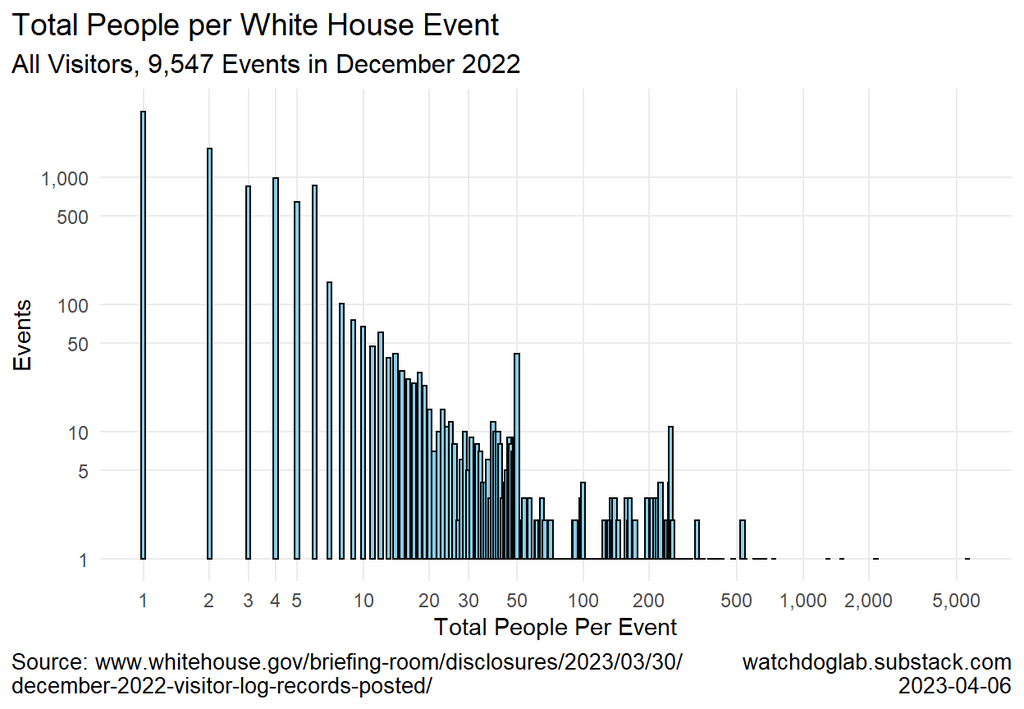

```r
ggplot(eventCountsByGroup, aes(x = `Total People`, y= Events))  +
  geom_bar(stat = "identity",
           fill = COLOR_BAR,  color = "black", width = 0.02)    +
  scale_x_log10(breaks = c(1:5, 10, 20, 30, 50,
                           100, 200, 500, 1000, 2000, 5000),
                labels = scales::comma)                         +
  scale_y_log10(breaks = c(1, 5, 10, 50, 100, 500,
                           1000, 5000, 10000, 15000, 20000),
                labels = scales::comma)                         +
  labs(
        title    = "Total People per White House Event",
        subtitle = paste0("All Visitors, ", comma(nrow(events)),
                          " Events in ", targetMonthName),
        x = "Total People Per Event",
        y = "Events",
        caption = c(SOURCE, stamp)
      )
```

## 4.2 POTUS Events

Not sure why, but x-axis scaling is not very dynamic unless filtered to only GROUP of interest.

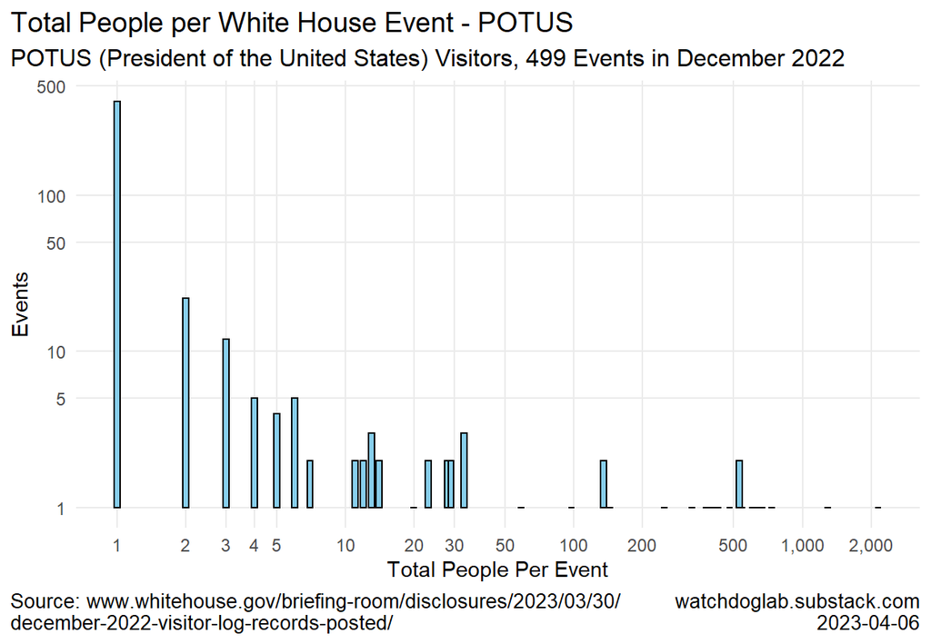

```r
eventCountsByGroup               |>
  select(`Total People`, POTUS)  |>
  filter(POTUS > 0)              |>
ggplot(aes(x = `Total People`, y= POTUS))                             +
  geom_bar(stat = "identity",
           fill = COLOR_BAR,  color = "black", width = 0.025)         +
  scale_x_log10(breaks = c(1:5, 10, 20, 30, 50,
                           100, 200, 500, 1000, 2000, 5000),
                labels = scales::comma)                               +
  scale_y_log10(breaks = c(1, 5, 10, 50, 100, 500,
                           1000, 5000, 10000, 15000, 20000),
                labels = scales::comma)                               +
  labs(
        title    = "Total People per White House Event - POTUS",
        subtitle = paste0("POTUS (President of the United States) Visitors, ",
                          comma(sum(eventCountsByGroup$POTUS)),
                          " Events in ", targetMonthName),
        x = "Total People Per Event",
        y = "Events",
        caption = c(SOURCE, stamp)
      )
```

## 4.3 VPOTUS Events

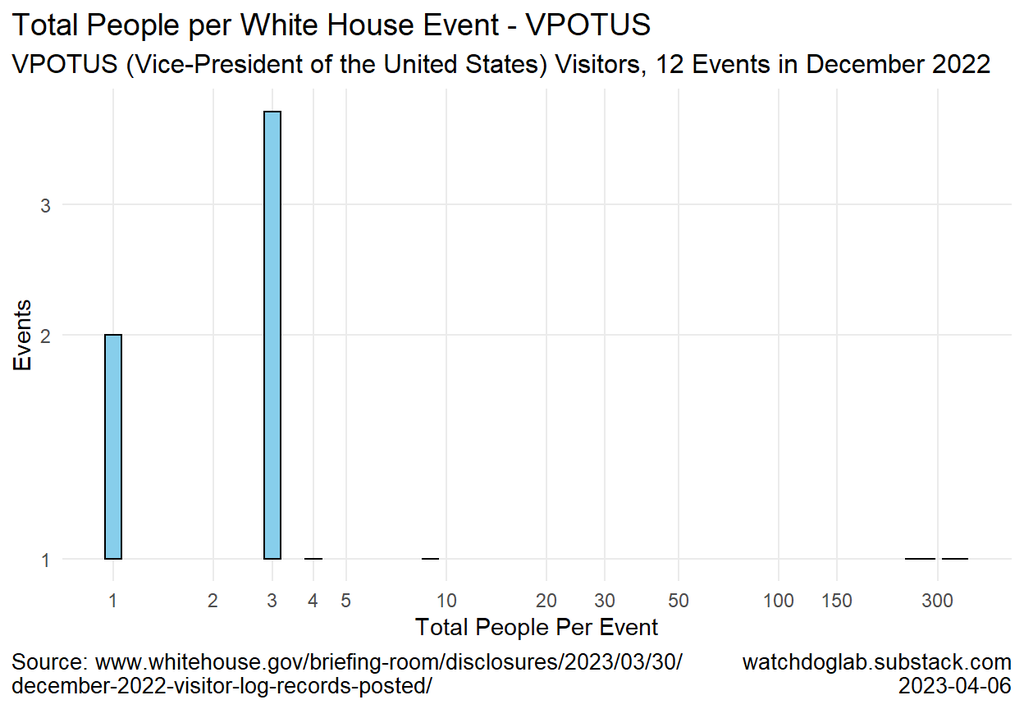

```r
eventCountsByGroup               |>
  select(`Total People`, VPOTUS) |>
  filter(VPOTUS > 0)             |>
ggplot(aes(x = `Total People`, y= VPOTUS))                            +
  geom_bar(stat = "identity",
           fill = COLOR_BAR, color = "black", width = 0.05)           +
  scale_x_log10(breaks = c(1:5, 10, 20, 30, 50,
                           100, 150, 300),
                labels = scales::comma)                               +
  scale_y_log10(#breaks = c(1, 5, 10, 20, 30, 40),
                labels = scales::comma)                               +
  labs(
        title    = "Total People per White House Event - VPOTUS",
        subtitle = paste0("VPOTUS (Vice-President of the United States) Visitors, ",
                          comma(sum(eventCountsByGroup$VPOTUS)),
                          " Events in ", targetMonthName),
        x = "Total People Per Event",
        y = "Events",
        caption = c(SOURCE, stamp)
      )
```

## 4.4 FLOTUS Events

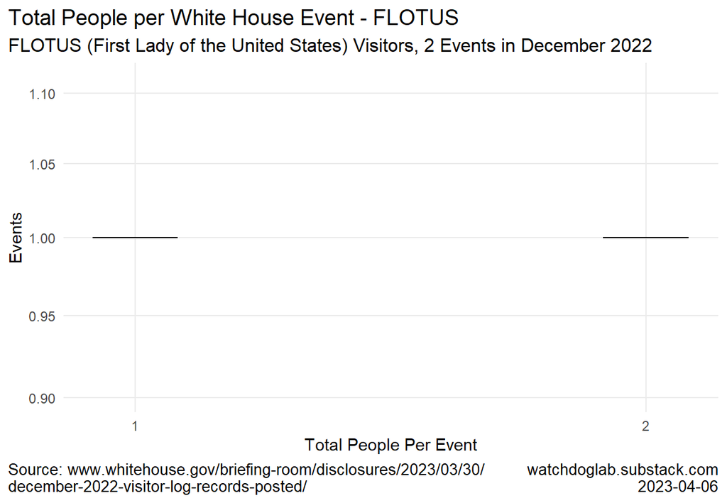

```r
eventCountsByGroup                |>
  select(`Total People`, FLOTUS)  |>
  filter(FLOTUS > 0)              |>
ggplot(aes(x = `Total People`, y= FLOTUS))                            +
  geom_bar(stat = "identity",
           fill = COLOR_BAR, color = "black", width = 0.05)           +
  scale_x_log10(breaks = c(1:5, 10, 20, 30, 50,
                           100, 150),
                labels = scales::comma)                               +
  scale_y_log10(# breaks = c(1, 5, 10, 20, 30, 40),
                labels = scales::comma)                               +
  labs(
        title    = "Total People per White House Event - FLOTUS",
         subtitle = paste0("FLOTUS (First Lady of the United States) Visitors, ",
                          comma(sum(eventCountsByGroup$FLOTUS)),
                           " Events in ", targetMonthName),
        x = "Total People Per Event",
        y = "Events",
        caption = c(SOURCE, stamp)
      )
```

## 4.5 Staff Events

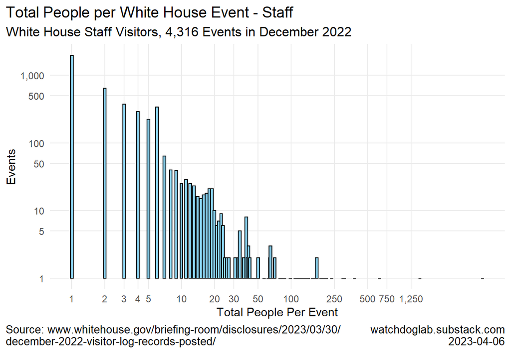

```r
eventCountsByGroup               |>
  select(`Total People`, Staff)  |>
  filter(Staff > 0)              |>
ggplot(aes(x = `Total People`, y= Staff))                             +
  geom_bar(stat = "identity",
           fill = COLOR_BAR,  color = "black", width = 0.025)         +
  scale_x_log10(breaks = c(1:5, 10, 20, 30, 50,
                           100, 250, 500, 750, 1250),
                labels = scales::comma)                               +
  scale_y_log10(breaks = c(1, 5, 10, 50, 100, 500,
                           1000, 5000, 10000, 15000, 20000),
                labels = scales::comma)                               +
  labs(
        title    = "Total People per White House Event - Staff",
        subtitle = paste0("White House Staff Visitors, ",
                          comma(sum(eventCountsByGroup$Staff)),
                          " Events in ", targetMonthName),
        x = "Total People Per Event",
        y = "Events",
        caption = c(SOURCE, stamp)
      )
```

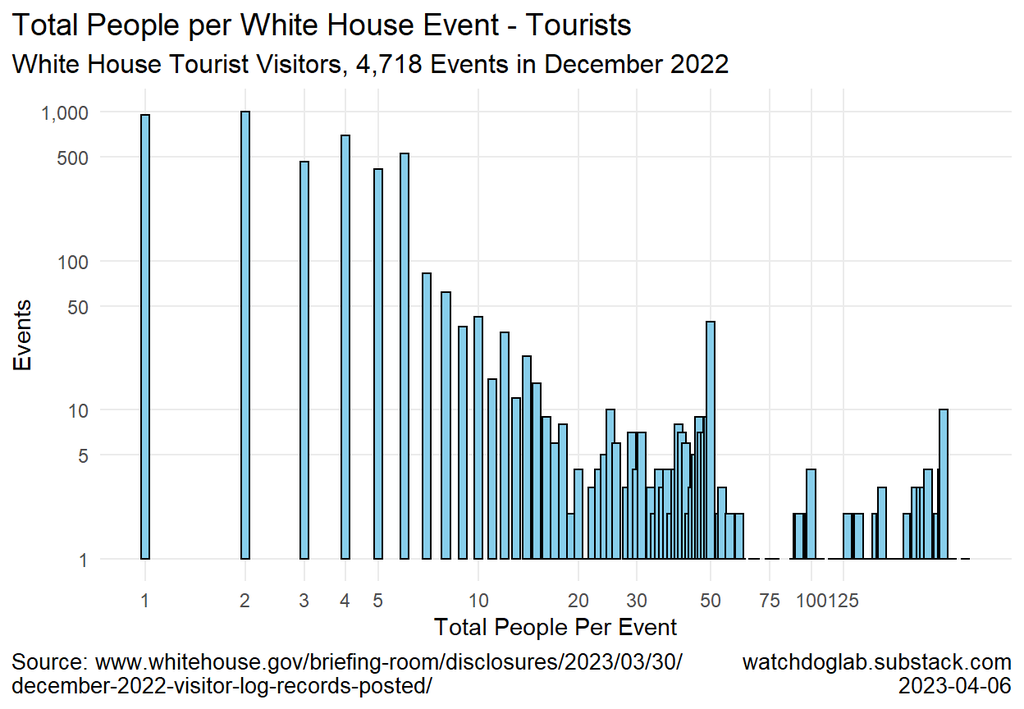

```r
eventCountsByGroup                 |>
  select(`Total People`, Tourist)  |>
  filter(Tourist > 0)              |>
ggplot(aes(x = `Total People`, y= Tourist))                           +
  geom_bar(stat = "identity",
           fill = COLOR_BAR,  color = "black", width = 0.025)         +
  scale_x_log10(breaks = c(1:5, 10, 20, 30, 50, 75, 100, 125),
                labels = scales::comma)                               +
  scale_y_log10(breaks = c(1, 5, 10, 50, 100, 500,
                           1000, 2000, 4000, 5000, 7000),
                labels = scales::comma)                               +
  labs(
        title    = "Total People per White House Event - Tourists",
        subtitle = paste0("White House Tourist Visitors, ",
                          comma(sum(eventCountsByGroup$Tourist)),
                          " Events in ", targetMonthName),
        x = "Total People Per Event",
        y = "Events",
        caption = c(SOURCE, stamp)
      )
```

# 5 Event Start Date Hour

Next time: use function for the Hour plots

## 5.1 Overall

Most of the Hour = 0 values are caused by missing time fields with date-only values.

```r
hourCounts <-
  events         |>
  group_by(Hour) |>
  count()

nrow(hourCounts)
```

```
[1] 21
```

```r
sum(hourCounts$n)
```

```
[1] 9547
```

Would like to use `coord_polar`for 24-hour clock here but it is fickle or has bugs.

Oddly, must expand left x-limit or first bar is clipped when present – this as also a problem with `coord_polar`

```r
hourCountsLessMissing <-
  hourCounts  |>
  filter(Hour != 0)

sum(hourCountsLessMissing$n)
```

```
[1] 9547
```

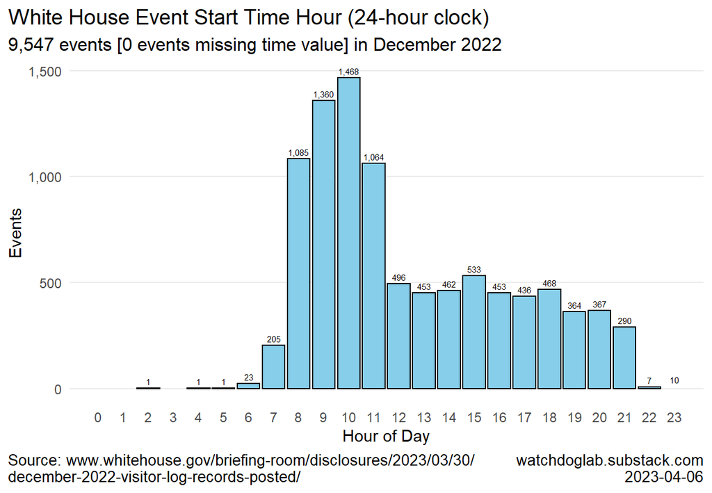

```r
ggplot(hourCountsLessMissing)          +
  geom_bar(aes(x = Hour, y = n),
           stat = "identity",
           fill = COLOR_BAR,  color = "black")               +

  scale_x_continuous(limits = c(0, 23),
                     breaks = seq(0, 23))                    +
  scale_y_continuous(labels = scales::comma)                 +

  geom_text(aes(x = Hour, y = n, label = comma(n)),
            vjust = -0.5, hjust = 0.5, size = 2, angle = 0) +

  labs(title = "White House Event Start Time Hour (24-hour clock)",
       subtitle = paste0(comma(sum(hourCountsLessMissing$n)), " events [",
                         comma(sum(hourCounts$n) -
                               sum(hourCountsLessMissing$n)),
                         " events missing time value] ",
                         "in ", targetMonthName),
       x = "Hour of Day",
       y = "Events",
       caption = c(SOURCE, stamp))                           +
  theme(panel.grid.major.x    = element_blank())
```

## 5.2 By Group

```r
hourCountsByGroup <-
  events                                         |>
  group_by(GROUP)                                |>
  count()

hourCountsByGroup |> Show(height = "200px")
```

| GROUP | n |
| --- | --- |
| POTUS | 499 |
| VPOTUS | 12 |
| FLOTUS | 2 |
| Staff | 4316 |
| Tourist | 4718 |

```r
hourCountsByGroupYear <-
  events                                            |>
  mutate(Year = substr(APPT_START_DATE,  1,  4)  |>
                as.numeric(),
         Hour = substr(APPT_START_DATE, 12, 13)  |>
                as.numeric())                        |>
  group_by(GROUP, Year)                             |>
  count(Hour)

hourCountsByGroupYear |> Show(height = "200px")
```

| GROUP | Year | Hour | n |
| --- | --- | --- | --- |
| POTUS | 2022 | 6 | 1 |
| POTUS | 2022 | 7 | 2 |
| POTUS | 2022 | 8 | 7 |
| POTUS | 2022 | 9 | 4 |
| POTUS | 2022 | 10 | 11 |
| POTUS | 2022 | 11 | 10 |
| POTUS | 2022 | 12 | 19 |
| POTUS | 2022 | 13 | 14 |
| POTUS | 2022 | 14 | 97 |
| POTUS | 2022 | 15 | 48 |
| POTUS | 2022 | 16 | 16 |
| POTUS | 2022 | 17 | 26 |
| POTUS | 2022 | 18 | 121 |
| POTUS | 2022 | 19 | 96 |
| POTUS | 2022 | 20 | 25 |
| POTUS | 2022 | 21 | 2 |
| VPOTUS | 2022 | 13 | 2 |
| VPOTUS | 2022 | 14 | 3 |
| VPOTUS | 2022 | 15 | 2 |
| VPOTUS | 2022 | 18 | 5 |
| FLOTUS | 2022 | 8 | 1 |
| FLOTUS | 2022 | 9 | 1 |
| Staff | 2022 | 2 | 1 |
| Staff | 2022 | 4 | 1 |
| Staff | 2022 | 5 | 1 |
| Staff | 2022 | 6 | 22 |
| Staff | 2022 | 7 | 68 |
| Staff | 2022 | 8 | 181 |
| Staff | 2022 | 9 | 279 |
| Staff | 2022 | 10 | 380 |
| Staff | 2022 | 11 | 350 |
| Staff | 2022 | 12 | 357 |
| Staff | 2022 | 13 | 410 |
| Staff | 2022 | 14 | 355 |
| Staff | 2022 | 15 | 387 |
| Staff | 2022 | 16 | 327 |
| Staff | 2022 | 17 | 305 |
| Staff | 2022 | 18 | 214 |
| Staff | 2022 | 19 | 174 |
| Staff | 2022 | 20 | 253 |
| Staff | 2022 | 21 | 234 |
| Staff | 2022 | 22 | 7 |
| Staff | 2022 | 23 | 10 |
| Tourist | 2022 | 7 | 135 |
| Tourist | 2022 | 8 | 896 |
| Tourist | 2022 | 9 | 1076 |
| Tourist | 2022 | 10 | 1077 |
| Tourist | 2022 | 11 | 704 |
| Tourist | 2022 | 12 | 120 |
| Tourist | 2022 | 13 | 27 |
| Tourist | 2022 | 14 | 7 |
| Tourist | 2022 | 15 | 96 |
| Tourist | 2022 | 16 | 110 |
| Tourist | 2022 | 17 | 105 |
| Tourist | 2022 | 18 | 128 |
| Tourist | 2022 | 19 | 94 |
| Tourist | 2022 | 20 | 89 |
| Tourist | 2022 | 21 | 54 |

```r
write_xlsx(hourCountsByGroupYear,
           paste0("Target-", targetMonth, "-",
                  "White-House-Event-Start-Hour-by-Group-",
                  DATA_RELEASE, ".xlsx"))
```

### 5.2.1 POTUS

```r
hourCounts <-
  events                   |>
  filter(GROUP == "POTUS") |>
  group_by(Hour)           |>
  count()

nrow(hourCounts)
```

```
[1] 16
```

```r
sum(hourCounts$n)
```

```
[1] 499
```

```r
hourCountsLessMissing <-
  hourCounts  |>
  filter(Hour != 0)

sum(hourCountsLessMissing$n)
```

```
[1] 499
```

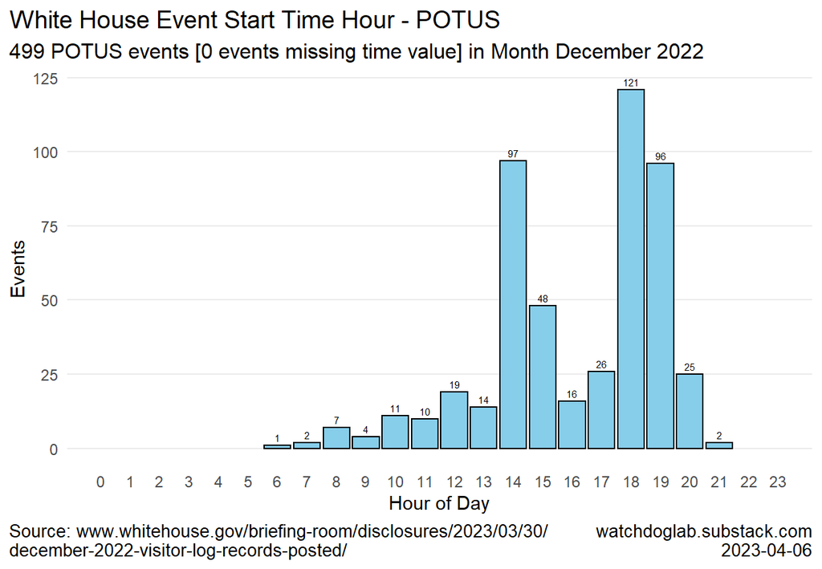

```r
ggplot(hourCountsLessMissing)          +
  geom_bar(aes(x = Hour, y = n),
           stat = "identity",
           fill = COLOR_BAR,  color = "black")               +

   scale_x_continuous(limits = c(0, 23),
                     breaks = seq(0, 23))                    +
  scale_y_continuous(labels = scales::comma)                 +

  geom_text(aes(x = Hour, y = n, label = comma(n)),
            vjust = -0.5, hjust = 0.5, size = 2, angle = 0) +

  labs(title = "White House Event Start Time Hour - POTUS",
       subtitle = paste0(comma(sum(hourCountsLessMissing$n)), " POTUS events [",
                         comma(sum(hourCounts$n) -
                               sum(hourCountsLessMissing$n)),
                         " events missing time value] ",
                         "in Month ", targetMonthName),
       x = "Hour of Day",
       y = "Events",
       caption = c(SOURCE, stamp))                           +
  theme(panel.grid.major.x    = element_blank())
```

### 5.2.2 VPOTUS

```r
hourCounts <-
  events                    |>
  filter(GROUP == "VPOTUS") |>
  group_by(Hour)            |>
  count()

nrow(hourCounts)
```

```
[1] 4
```

```r
sum(hourCounts$n)
```

```
[1] 12
```

```r
hourCountsLessMissing <-
  hourCounts  |>
  filter(Hour != 0)

sum(hourCountsLessMissing$n)
```

```
[1] 12
```

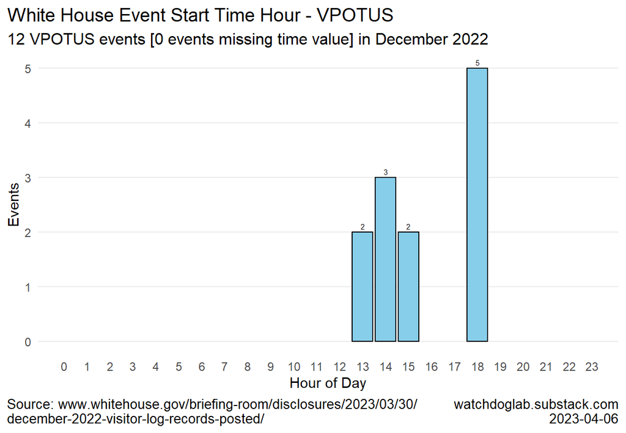

```r
ggplot(hourCountsLessMissing)          +
  geom_bar(aes(x = Hour, y = n),
           stat = "identity",
           fill = COLOR_BAR,  color = "black")               +

  scale_x_continuous(limits = c(0, 23),
                     breaks = seq(0, 23))                    +
  scale_y_continuous(labels = scales::comma)                 +

  geom_text(aes(x = Hour, y = n, label = comma(n)),
            vjust = -0.5, hjust = 0.5, size = 2, angle = 0) +

  labs(title = "White House Event Start Time Hour - VPOTUS",
       subtitle = paste0(comma(sum(hourCountsLessMissing$n)), " VPOTUS events [",
                         comma(sum(hourCounts$n) -
                               sum(hourCountsLessMissing$n)),
                         " events missing time value] ",
                         "in ", targetMonthName),
       x = "Hour of Day",
       y = "Events",
       caption = c(SOURCE, stamp))                           +
  theme(panel.grid.major.x    = element_blank())
```

### 5.2.3 FLOTUS

```r
hourCounts <-
  events                    |>
  filter(GROUP == "FLOTUS") |>
  group_by(Hour)            |>
  count()

nrow(hourCounts)
```

```
[1] 2
```

```r
sum(hourCounts$n)
```

```
[1] 2
```

```r
hourCountsLessMissing <-
  hourCounts  |>
  filter(Hour != 0)

sum(hourCountsLessMissing$n)
```

```
[1] 2
```

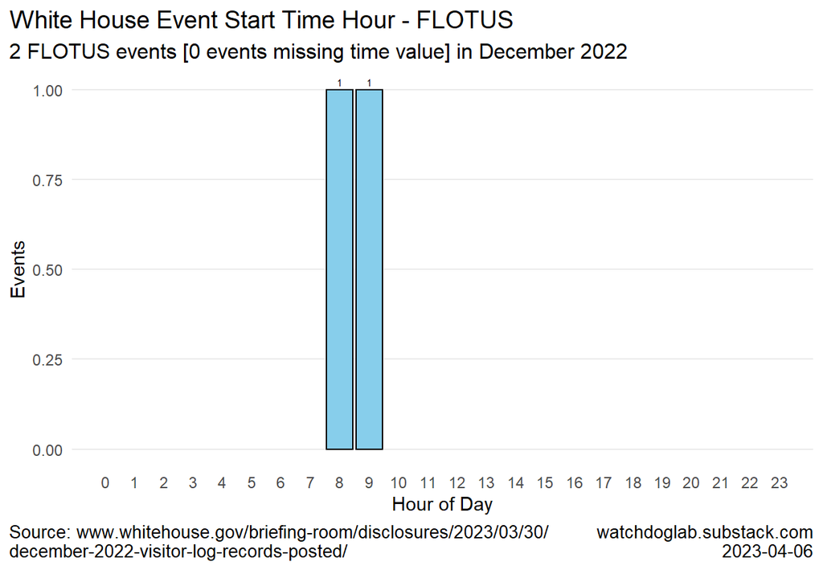

```r
ggplot(hourCountsLessMissing)          +
  geom_bar(aes(x = Hour, y = n),
           stat = "identity",
           fill = COLOR_BAR,  color = "black")               +

  scale_x_continuous(limits = c(0, 23),
                     breaks = seq(0, 23))                    +
  scale_y_continuous(labels = scales::comma)                 +

  geom_text(aes(x = Hour, y = n, label = comma(n)),
            vjust = -0.5, hjust = 0.5, size = 2, angle = 0) +

  labs(title = "White House Event Start Time Hour - FLOTUS",
       subtitle = paste0(comma(sum(hourCountsLessMissing$n)), " FLOTUS events [",
                         comma(sum(hourCounts$n) -
                               sum(hourCountsLessMissing$n)),
                         " events missing time value] ",
                         "in ", targetMonthName),
       x = "Hour of Day",
       y = "Events",
       caption = c(SOURCE, stamp))                           +
  theme(panel.grid.major.x    = element_blank())
```

### 5.2.4 Staff

```r
hourCounts <-
  events                   |>
  filter(GROUP == "Staff") |>
  group_by(Hour)           |>
  count()

nrow(hourCounts)
```

```
[1] 21
```

```r
sum(hourCounts$n)
```

```
[1] 4316
```

```r
hourCountsLessMissing <-
  hourCounts  |>
  filter(Hour != 0)

sum(hourCountsLessMissing$n)
```

```
[1] 4316
```

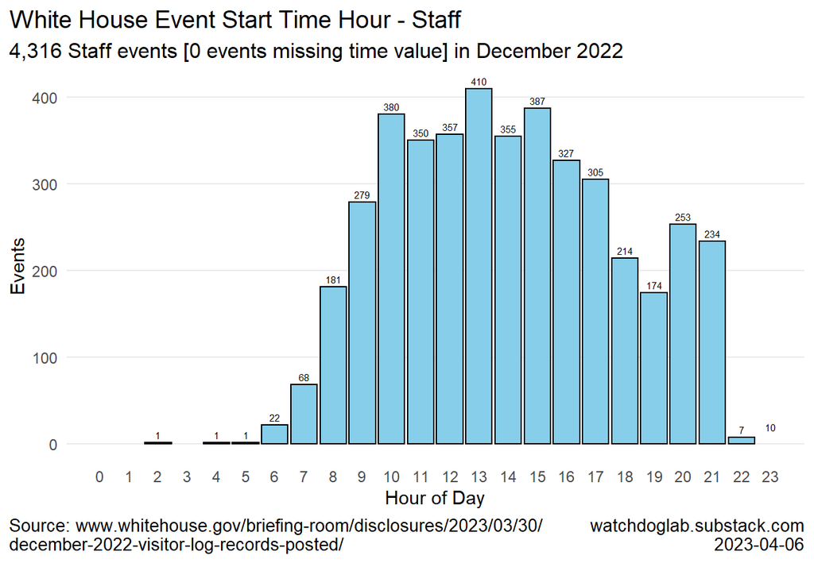

```r
ggplot(hourCountsLessMissing)          +
  geom_bar(aes(x = Hour, y = n),
           stat = "identity",
           fill = COLOR_BAR,  color = "black")               +

  scale_x_continuous(limits = c(0, 23),
                     breaks = seq(0, 23))                    +
  scale_y_continuous(labels = scales::comma)                 +

  geom_text(aes(x = Hour, y = n, label = comma(n)),
            vjust = -0.5, hjust = 0.5, size = 2, angle = 0) +

  labs(title = "White House Event Start Time Hour - Staff",
       subtitle = paste0(comma(sum(hourCountsLessMissing$n)), " Staff events [",
                         comma(sum(hourCounts$n) -
                               sum(hourCountsLessMissing$n)),
                         " events missing time value] ",
                         "in ", targetMonthName),
       x = "Hour of Day",
       y = "Events",
       caption = c(SOURCE, stamp))                           +
  theme(panel.grid.major.x    = element_blank())
```

### 5.2.5 Tourist

```r
hourCounts <-
  events                     |>
  filter(GROUP == "Tourist") |>
  group_by(Hour)             |>
  count()

nrow(hourCounts)
```

```
[1] 15
```

```r
sum(hourCounts$n)
```

```
[1] 4718
```

```r
hourCountsLessMissing <-
  hourCounts  |>
  filter(Hour != 0)

sum(hourCountsLessMissing$n)
```

```
[1] 4718
```

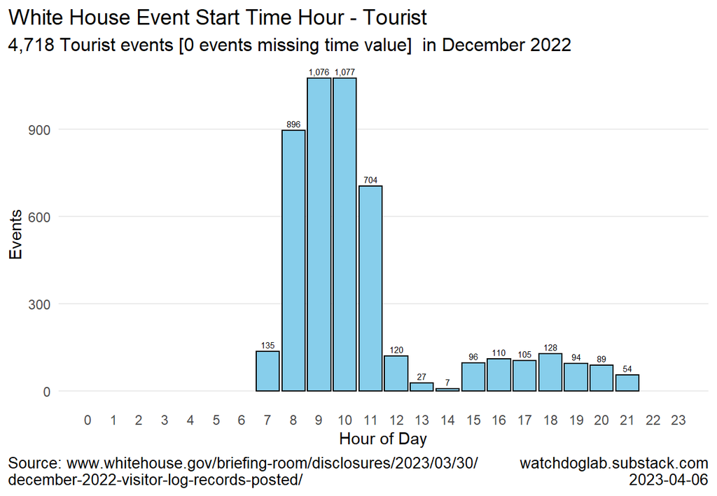

```r
ggplot(hourCountsLessMissing)          +
  geom_bar(aes(x = Hour, y = n),
           stat = "identity",
           fill = COLOR_BAR,  color = "black")               +

  scale_x_continuous(limits = c(0, 23),
                     breaks = seq(0, 23))                    +
  scale_y_continuous(labels = scales::comma)                 +

  geom_text(aes(x = Hour, y = n, label = comma(n)),
            vjust = -0.5, hjust = 0.5, size = 2, angle = 0) +

  labs(title = "White House Event Start Time Hour - Tourist",
       subtitle = paste0(comma(sum(hourCountsLessMissing$n)), " Tourist events [",
                         comma(sum(hourCounts$n) -
                               sum(hourCountsLessMissing$n)),
                         " events missing time value] ",
                         " in ", targetMonthName),
       x = "Hour of Day",
       y = "Events",
       caption = c(SOURCE, stamp))                           +
  theme(panel.grid.major.x    = element_blank())
```

### 5.2.6 After-Hour Tourists

```r
afterHourTouristEvents <-
  events                     |>
  filter(GROUP == "Tourist",
         Hour  >= 15)        |>
  select(Event)              |>
  unique()

nrow(afterHourTouristEvents)
```

```
[1] 676
```

```r
afterHourTourists <-
  wh   |>
  inner_join(afterHourTouristEvents, by = "Event") %>%
  arrange(APPT_START_DATE, VISITEE, VISITOR)

nrow(afterHourTourists)
```

```
[1] 17028
```

```r
write_xlsx(afterHourTourists,
           paste0("Target-", targetMonth, "-",
                  "White-House-After-Hours-Tourists-",
                  targetMonth, "-",
                  DATA_RELEASE, ".xlsx"))
```

## 5.3 Hour by Month

```r
hourCountsByGroupYearMonth <-
  events                                          |>
  mutate(Year  = substr(APPT_START_DATE,  1,  4),
         Month = substr(APPT_START_DATE,  6,  7),
         Hour  = substr(APPT_START_DATE, 12, 13)) |>
  group_by(GROUP, Year, Month, Hour)              |>
  count()                                         |>
  arrange(Year, Month, Hour, GROUP)

hourCountsByGroupYearMonth |> Show(height = "200px")
```

| GROUP | Year | Month | Hour | n |
| --- | --- | --- | --- | --- |
| Staff | 2022 | 12 | 02 | 1 |
| Staff | 2022 | 12 | 04 | 1 |
| Staff | 2022 | 12 | 05 | 1 |
| POTUS | 2022 | 12 | 06 | 1 |
| Staff | 2022 | 12 | 06 | 22 |
| POTUS | 2022 | 12 | 07 | 2 |
| Staff | 2022 | 12 | 07 | 68 |
| Tourist | 2022 | 12 | 07 | 135 |
| POTUS | 2022 | 12 | 08 | 7 |
| FLOTUS | 2022 | 12 | 08 | 1 |
| Staff | 2022 | 12 | 08 | 181 |
| Tourist | 2022 | 12 | 08 | 896 |
| POTUS | 2022 | 12 | 09 | 4 |
| FLOTUS | 2022 | 12 | 09 | 1 |
| Staff | 2022 | 12 | 09 | 279 |
| Tourist | 2022 | 12 | 09 | 1076 |
| POTUS | 2022 | 12 | 10 | 11 |
| Staff | 2022 | 12 | 10 | 380 |
| Tourist | 2022 | 12 | 10 | 1077 |
| POTUS | 2022 | 12 | 11 | 10 |
| Staff | 2022 | 12 | 11 | 350 |
| Tourist | 2022 | 12 | 11 | 704 |
| POTUS | 2022 | 12 | 12 | 19 |
| Staff | 2022 | 12 | 12 | 357 |
| Tourist | 2022 | 12 | 12 | 120 |
| POTUS | 2022 | 12 | 13 | 14 |
| VPOTUS | 2022 | 12 | 13 | 2 |
| Staff | 2022 | 12 | 13 | 410 |
| Tourist | 2022 | 12 | 13 | 27 |
| POTUS | 2022 | 12 | 14 | 97 |
| VPOTUS | 2022 | 12 | 14 | 3 |
| Staff | 2022 | 12 | 14 | 355 |
| Tourist | 2022 | 12 | 14 | 7 |
| POTUS | 2022 | 12 | 15 | 48 |
| VPOTUS | 2022 | 12 | 15 | 2 |
| Staff | 2022 | 12 | 15 | 387 |
| Tourist | 2022 | 12 | 15 | 96 |
| POTUS | 2022 | 12 | 16 | 16 |
| Staff | 2022 | 12 | 16 | 327 |
| Tourist | 2022 | 12 | 16 | 110 |
| POTUS | 2022 | 12 | 17 | 26 |
| Staff | 2022 | 12 | 17 | 305 |
| Tourist | 2022 | 12 | 17 | 105 |
| POTUS | 2022 | 12 | 18 | 121 |
| VPOTUS | 2022 | 12 | 18 | 5 |
| Staff | 2022 | 12 | 18 | 214 |
| Tourist | 2022 | 12 | 18 | 128 |
| POTUS | 2022 | 12 | 19 | 96 |
| Staff | 2022 | 12 | 19 | 174 |
| Tourist | 2022 | 12 | 19 | 94 |
| POTUS | 2022 | 12 | 20 | 25 |
| Staff | 2022 | 12 | 20 | 253 |
| Tourist | 2022 | 12 | 20 | 89 |
| POTUS | 2022 | 12 | 21 | 2 |
| Staff | 2022 | 12 | 21 | 234 |
| Tourist | 2022 | 12 | 21 | 54 |
| Staff | 2022 | 12 | 22 | 7 |
| Staff | 2022 | 12 | 23 | 10 |

```r
write_xlsx(hourCountsByGroupYearMonth,
           paste0("Target-", targetMonth, "-",
                  "White-House-Event-Start-Hour-by-Group-Month-",
                  DATA_RELEASE, ".xlsx"))
```

# 6 Visitors by Day

```r
byDay <-
  wh                            |>
  mutate(APPT_DAY = substr(APPT_START_DATE,  1, 10))  |>   # YYYY-MM-DD

  group_by(APPT_DAY, GROUP)     |>
  count()                       |>
  ungroup()                     |>

  spread(GROUP, n, fill = 0) |>
  mutate(
          Visitors           = rowSums(across(POTUS:Tourist)),
          PVF                = POTUS + VPOTUS + FLOTUS,
          Day                = mday(APPT_DAY)
        )                    |>
  relocate(Day)

dim(byDay)
```

```
[1] 31  9
```

```r
byDay |> Show(bigMark = ",", height = "300px")
```

| Day | APPT_DAY | POTUS | VPOTUS | FLOTUS | Staff | Tourist | Visitors | PVF |
| --- | --- | --- | --- | --- | --- | --- | --- | --- |
| 1 | 2022-12-01 | 430 | 0 | 0 | 6,687 | 0 | 7,117 | 430 |
| 2 | 2022-12-02 | 0 | 0 | 0 | 1,041 | 0 | 1,041 | 0 |
| 3 | 2022-12-03 | 0 | 0 | 0 | 1,154 | 5,836 | 6,990 | 0 |
| 4 | 2022-12-04 | 270 | 0 | 0 | 172 | 0 | 442 | 270 |
| 5 | 2022-12-05 | 985 | 0 | 0 | 507 | 0 | 1,492 | 985 |
| 6 | 2022-12-06 | 0 | 3 | 0 | 1,330 | 1,948 | 3,281 | 3 |
| 7 | 2022-12-07 | 876 | 10 | 0 | 1,269 | 1,504 | 3,659 | 886 |
| 8 | 2022-12-08 | 520 | 0 | 0 | 920 | 0 | 1,440 | 520 |
| 9 | 2022-12-09 | 921 | 0 | 0 | 843 | 1,828 | 3,592 | 921 |
| 10 | 2022-12-10 | 1,502 | 0 | 0 | 401 | 0 | 1,903 | 1,502 |
| 11 | 2022-12-11 | 21 | 0 | 0 | 389 | 5,106 | 5,516 | 21 |
| 12 | 2022-12-12 | 1,030 | 0 | 0 | 1,061 | 0 | 2,091 | 1,030 |
| 13 | 2022-12-13 | 4,299 | 0 | 0 | 1,793 | 1,546 | 7,638 | 4,299 |
| 14 | 2022-12-14 | 250 | 0 | 0 | 808 | 0 | 1,058 | 250 |
| 15 | 2022-12-15 | 622 | 0 | 0 | 682 | 89 | 1,393 | 622 |
| 16 | 2022-12-16 | 1,295 | 0 | 0 | 834 | 3,126 | 5,255 | 1,295 |
| 17 | 2022-12-17 | 0 | 0 | 0 | 1,283 | 5,138 | 6,421 | 0 |
| 18 | 2022-12-18 | 0 | 327 | 0 | 679 | 5,795 | 6,801 | 327 |
| 19 | 2022-12-19 | 725 | 635 | 0 | 1,399 | 2,227 | 4,986 | 1,360 |
| 20 | 2022-12-20 | 409 | 0 | 3 | 546 | 0 | 958 | 412 |
| 21 | 2022-12-21 | 764 | 179 | 0 | 535 | 0 | 1,478 | 943 |
| 22 | 2022-12-22 | 941 | 0 | 0 | 366 | 5 | 1,312 | 941 |
| 23 | 2022-12-23 | 0 | 0 | 0 | 429 | 9,672 | 10,101 | 0 |
| 24 | 2022-12-24 | 0 | 0 | 0 | 62 | 0 | 62 | 0 |
| 25 | 2022-12-25 | 0 | 0 | 0 | 33 | 0 | 33 | 0 |
| 26 | 2022-12-26 | 0 | 0 | 0 | 21 | 0 | 21 | 0 |
| 27 | 2022-12-27 | 0 | 0 | 0 | 98 | 0 | 98 | 0 |
| 28 | 2022-12-28 | 0 | 0 | 0 | 193 | 0 | 193 | 0 |
| 29 | 2022-12-29 | 0 | 0 | 0 | 199 | 0 | 199 | 0 |
| 30 | 2022-12-30 | 0 | 0 | 0 | 165 | 0 | 165 | 0 |
| 31 | 2022-12-31 | 0 | 0 | 0 | 282 | 0 | 282 | 0 |

```r
write_xlsx(byDay,
           paste0("Target-", targetMonth, "-",
                  "White-House-Visitors-by-Day-Table-",
                  DATA_RELEASE, ".xlsx"))
```

```r
longFormat <-
  byDay                   |>
  pivot_longer(
                cols      = c("POTUS", "VPOTUS", "FLOTUS",
                              "Staff", "Tourist",
                              "Visitors", "PVF"),
                names_to  = "Group",
                values_to = "Visits"
               )

dim(longFormat)
```

```
[1] 217   4
```

Will need to filter for Groups of interest in any plot since there is double counting.

```r
longFormat |> head(10) |> Show()
```

| Day | APPT_DAY | Group | Visits |
| --- | --- | --- | --- |
| 1 | 2022-12-01 | POTUS | 430 |
| 1 | 2022-12-01 | VPOTUS | 0 |
| 1 | 2022-12-01 | FLOTUS | 0 |
| 1 | 2022-12-01 | Staff | 6687 |
| 1 | 2022-12-01 | Tourist | 0 |
| 1 | 2022-12-01 | Visitors | 7117 |
| 1 | 2022-12-01 | PVF | 430 |
| 2 | 2022-12-02 | POTUS | 0 |
| 2 | 2022-12-02 | VPOTUS | 0 |
| 2 | 2022-12-02 | FLOTUS | 0 |

## 6.1 PVL = POTUS + VPOTUS + FLOTUS

Use default blue color for POTUS, but two different sets of qualitative pairs for plots below.

```r
POTUS_COLOR <- "#619CFF"
set2 <- brewer.pal( 8, "Set2")  # Brewer qualitative palettes
set3 <- brewer.pal(12, "Set3")
```

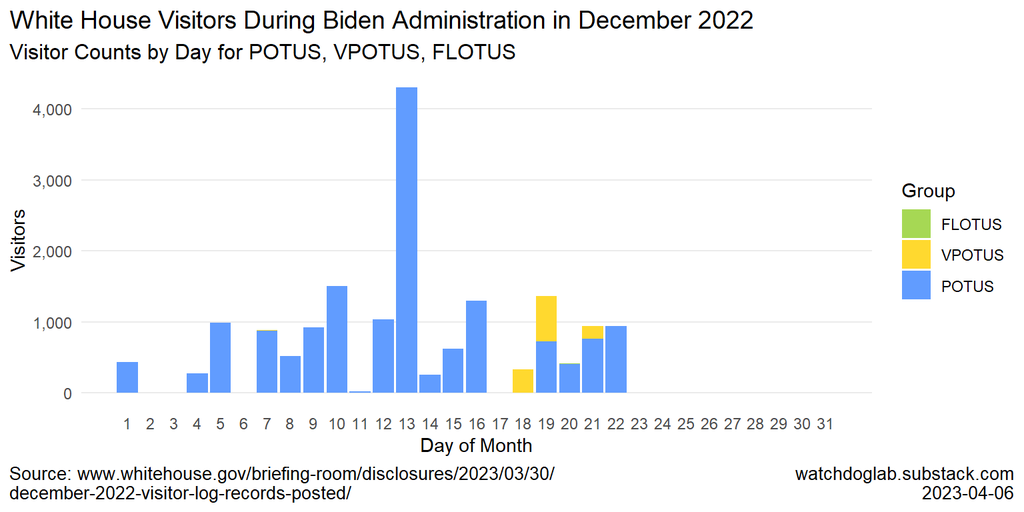

```r
longFormat                                                               |>
  filter(Group %in% c("POTUS", "VPOTUS", "FLOTUS"))                      |>
  mutate(Group = factor(Group, levels = c("FLOTUS", "VPOTUS", "POTUS"))) |>
  ggplot(aes(x = Day, y = Visits, fill = Group))        +
  geom_bar(position = "stack", stat = "identity")       +
  scale_x_continuous(breaks = 1:nrow(eventCountsByDay)) +
  scale_y_continuous(
                      labels = scales::comma
                    )                                   +
                             # FLOTUS    VPOTUS    POTUS
  scale_fill_manual(values = c(set2[5],  set2[6],  POTUS_COLOR))  +

  labs(
        title    = paste0("White House Visitors During Biden Administration in ", targetMonthName),
        subtitle = paste0("Visitor Counts by Day for POTUS, VPOTUS, FLOTUS "),
        x = "Day of Month",
        y = "Visitors",
        caption = c(SOURCE, stamp)
      )                                                 +
  theme(panel.grid.major.x    = element_blank(),
        legend.position = "right")
```

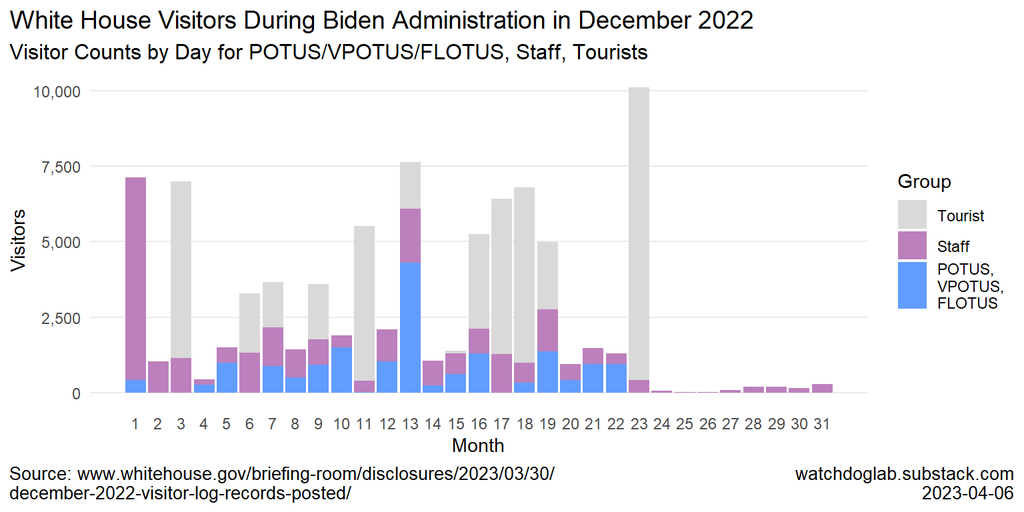

```r
longFormat                                                             |>
  filter(Group %in% c("PVF", "Staff", "Tourist"))                      |>
  mutate(Group = factor(Group, levels = c("Tourist", "Staff", "PVF"))) |>
  ggplot(aes(x = Day, y = Visits, fill = Group))        +
  geom_bar(position = "stack", stat = "identity")       +

  scale_y_continuous(labels = scales::comma)            +
  scale_x_continuous(breaks = 1:nrow(eventCountsByDay)) +

   scale_fill_manual(values=c(set3[9],  set3[10], POTUS_COLOR),
                    labels = c("Tourist", "Staff", "POTUS,\nVPOTUS,\nFLOTUS"))  +

  labs(
        title    = paste0("White House Visitors During Biden Administration in ", targetMonthName),
        subtitle = "Visitor Counts by Day for POTUS/VPOTUS/FLOTUS, Staff, Tourists",
        x = "Month",
        y = "Visitors",
        caption = c(SOURCE, stamp)
      )                                             +
  theme(panel.grid.major.x    = element_blank(),
        legend.position = "right")
```

# 7 Epilog

## 7.1

Processing time: 11.4 secs

2023-04-06 1225